# Cuestionario

01-09-2021

## Intro

- Durante el curso analizaremos conjuntos de datos y estimaremos modelos. Para ello utilizaremos un programa informático: **Gretl**
- Gretl es un programa informático con el que se pueden hacer **análisis estadísticos** y **estimar** una amplia gama de **modelos econométricos**.
- En esta práctica inicial haremos una **primera incursión en Gretl** a la vez que iremos recordamos algunos instrumentos y conceptos básicos de Estadística.

##### ¿Cómo me instalo Gretl?

- Gretl es un programa libre y gratuito. Puedes descargarlo en http://gretl.sourceforge.net/index.html

##### Guías de Gretl:

- No creo que necesitéis un manual de Gretl. Pienso que con la ayuda interna de Gretl es más que suficiente; eso sí, si quieres aprender en profundidad Gretl, entonces sí necesitas un manual.
- El mismo Gretl tiene diferentes documentos para aprender Gretl. En la pestaña Ayuda encontrarás varios documentos pdf. Los más interesantes son: Guía del usuario, Guía de instrucciones y Hansl primer. Están en inglés.
- El manual más reciente que conozco es este: http://gretl.sourceforge.net/gretl-help/gretl-guide.pdf. Son 386 paginas.
- Puedes encontrar fácilmente manuales en castellano buscando en internet. Aquí tienes algunos:
  - Manual de usuario en castellano. 47 páginas. http://ocw.uniovi.es/pluginfile.php/2958/mod_resource/content/1/T_1C,A_668/Gretl/Guia_Gretl.pdf
  - Guía Rápida de Gretl. 23 páginas. http://www.eco.uc3m.es/~cavelas/EconometriaI/Guia%20rapida%20de%20gretl.pdf
  - GRETL, the Gnu Regression, Econometrics and Time-series Library. A pesar del título, está escrito en castellano. Tiene 68 páginas. http://www.fce.unal.edu.co/uifce/proyectos-de-estudio/pdf/GRETL

## Ejercicio 1 (intro a Gretl)

Una vez te hayas instalado Gretl intenta hacer lo siguiente:

1. Abre el fichero de datos `datos_interes.xls` (lo tienes en aula virtual)
2. Visualiza las variables i_llarg y i_curt
3. Gráfico temporal de esas 2 variables.
4. Histograma/gráfico de barras/distribución de frecuencias para i_llarg. Interpreta. ¿i_llarg se distribuye aproximadamente como una normal?
5. Estadísticos descriptivos para i_llarg. Interpreta.
6. Gráfico de dispersión entre i_llarg y i_curt. Interpreta. ¿están relacionadas las 2 variables?
7. Gráfico de dispersión entre i_llarg y M2
8. Matriz de correlaciones entre i_llarg i_curt PIB IPC

## Ejercicio 2 (estimación a mano)

Con la información de la tabla adjunta:

| i | X | Y |
| --- | --- | --- |
| 1 | 5 | 6 |
| 2 | 7 | 3 |
| 3 | 4 | 9 |
| 4 | 3 | 3 |
| 5 | 6 | 9 |

1. Plantee un modelo de regresión lineal simple donde Y sea la variable dependiente y X la variable independiente.
2. Estime el modelo por los métodos que conozca.
3. Escriba el modelo estimado.
4. Interprete el valor del estimador que acompaña a la variable independiente o explicativa.
5. Calcule los valores ajustados de la variable dependiente.
6. Calcule los residuos.
7. Represente gráficamente los puntos de las observaciones (diagrama de dispersión o nube de puntos), la recta de regresión ajustada y señale los valores ajustados y los residuos.
8. Verifique el cumplimiento de las propiedades descriptivas de la regresión simple.
9. Descomponga la variación total de la variable dependiente en variación explicada por la regresión y variación residual.
10. Calcule el coeficiente de determinación por los métodos que conozca.
11. Interprete el valor del coeficiente de determinación.

## Ejercicio 3 (zoólogo)

| EJEMPLAR | PESO | LONGITUD |
| --- | --- | --- |
| 1 | 21 | 44 |
| 2 | 27 | 49 |
| 3 | 25 | 51 |
| 4 | 14 | 43 |
| 5 | 19 | 39 |

donde la variable PESO está expresada en kilogramos y la variable LONGITUD está expresada en centímetros. Los datos están en el fichero `datos_zoologo.gdt`

1. Plantee un MRLS que relacione el peso y la longitud de los animales.
2. Estime con ordenador el modelo anterior.
3. Interprete el “estimador” de la pendiente.
4. ¿Qué peso tendrá un animal de 45 centímetros?
5. Si un animal es tres centímetros más largo que otro, ¿qué diferencia de peso cabe esperar?
6. Interprete el valor del coeficiente de determinación.
7. Si el peso se expresa en gramos y la longitud en centímetros, ¿qué estimación se obtendrá?
8. Si el peso se expresa en kilogramos y la longitud en metros, ¿qué estimación se obtendrá?

## Ejercicio 4 (Y-X2-X3)

Con los resultados mostrados en el siguiente cuadro:

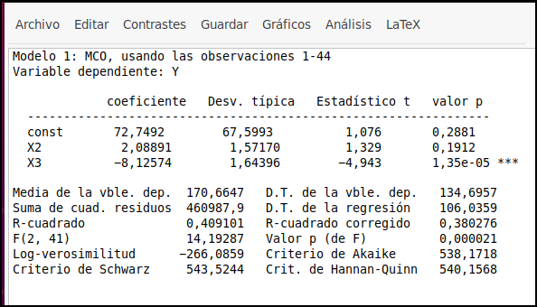

1. Contraste la significatividad de $\beta_{2}$
2. Contraste la significatividad de $\beta_{3}$
3. ¿Es $\beta_{2}$ igual a 4?
4. ¿Es $\beta_{3} = -2$?
5. Contraste la significatividad conjunta del modelo
6. Estime la varianza de las perturbaciones

## Ejercicio 5

Con 34 observaciones se ha estimado el siguiente modelo:

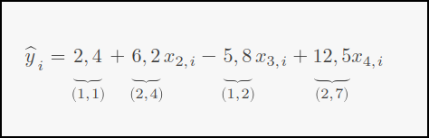

donde los valores entre paréntesis son las desviaciones típicas estimadas de los estimadores correspondientes (errores estándar).

1. Contraste la significatividad de la variable X4
2. Cuando X3 aumenta una unidad, ¿la variable Y disminuye 4 unidades?
3. Contraste si es igual a 2 frente a la posibilidad de que sea menor que 2
4. Contraste si es igual a 10 frente a la posibilidad de que sea mayor que 10

## Ejercicio 6 (sqrt-bdrms)

(Examen de enero de 2007) Con una muestra formada por 88 viviendas de una determinada zona se ha obtenido la siguiente estimación: $\hat{P} = 19,3 + 0,128 sqrft + 15,2 bdrms$ . Donde:

- **P**: precio de la vivienda en miles de dólares USA
- **sqrft**: superficie de la vivienda en pies cuadrados
- **bdrms**: número de dormitorios de la vivienda
1. Si se mantiene fija la superficie total de la vivienda, ¿cuál será el aumento estimado del precio de una vivienda si se le dota de un dormitorio adicional?
2. ¿Cuál será el aumento estimado del precio de una vivienda si se construye un dormitorio adicional aumentando también la superficie de la vivienda en 100 pies cuadrados?
3. Una vivienda de 2.500 pies cuadrados y 4 dormitorios se pone a la venta por 270.000 dólares. ¿Qué opina del precio?
4. Exprese el modelo estimado utilizando como unidad de medida de superficie el metro cuadrado (sqrmts) y expresando el precio en miles de euros

**NOTAS**: 1 pie cuadrado equivale aproximadamente a 0.1 metros cuadrados. Utilice como tipo de cambio 1 euro = 1.28 dólares USA.

## Ejercicio 7 (bolmad95)

Vamos a utilizar los datos del fichero `datos_bolmad95.gdt`. Este fichero recoge observaciones de 161 empresas españolas sobre las siguientes variables:

- **MARKTVAL** = Valor total de las acciones
- **BOOKVAL** = Valor contable
1. Análisis previo de los datos:
   1. ¿qué tipo de datos son?
   2. Obtén estadísticos descriptivos de las 2 variables.
   3. Representa las 2 variables en un gráfico de dispersión. ¿hay relación entre ellas?
   4. ¿Detectas algún valor anómalo?
2. Estima por MCO el siguiente modelo econométrico:
   1. Escribe la ecuación de la recta o modelo estimado
   2. Interpreta el coeficiente estimado para $\beta_{2}$
   3. Interpreta el coeficiente estimado para $\beta_{1}$
   4. Interpreta el valor de $R^{2}$
   5. ¿Qué problema crees que puede originar en la estimación el valor anómalo?
3. Elimina el valor anómalo y vuelve a estimar el modelo.
   1. Observa cómo cambia el coeficiente estimado.
   2. Representa la variable endógena estimada y los residuos.
   3. ¿Observas alguna relación entre los residuos y la variable explicativa?
4. Transforma las variables del modelo tomando logaritmos.
   1. Estima el modelo en logaritmos (modelo doblemente logarítmico)
   2. Interpreta el coeficiente estimado para $\beta_{2}$
   3. Obtén la variable dependiente estimada y los residuos para sacar conclusiones

## Ejercicio 8 (edad-mates)

Se desea analizar la relación existente entre la edad de los maestros y la calificación matemática de sus alumnos. Para ello se dispone del archivo `datos_mates.gdt` que contiene una muestra formada por 1.000 observaciones de las siguientes variables:

- **EDAT**: Edad del maestro en años
- **MATES**: Puntuación obtenida por el alumno en una prueba de matemáticas (escala de 0 a 10)
  1. Plantee un modelo de regresión que relacione la edad del maestro con la puntuación en el examen de los estudiantes
  2. Estime con el ordenador el modelo anterior
  3. Interprete el estimador de la pendiente
  4. Introduce en el modelo un nuevo regresor, concretamente la edad del maestro en forma cuadrática. En este nuevo modelo interpreta la relación entre la edad de los maestros y la puntuación
  5. ¿Qué notas cabe esperar en los alumnos de maestros de 30, 40, 50 i 60 años?
  6. ¿Cuál sería la edad óptima de los maestros?
  7. Comente los resultados

## Ejercicio 9 (salario-educación)

Con los datos del fichero `datos_salario_educacion.gdt` estime por MCO el siguiente modelo:

$$salario = \beta_{1} + \beta_{2} educacion + \beta_{3} experiencia + \beta_{4} antiguedad + u$$

Si no se dice lo contrario realice los contrastes al 5%. En todos los cálculos utilice 3 decimales.

Una vez estimado el modelo conteste a las siguientes cuestiones

1. Realice y explique con palabras de forma detallada el contraste la significatividad individual de la variable educación.
2. La estimación puntual de $\beta_{2}$ es 0,598 ¿es la estimación óptima? Explique
3. ¿Cómo ha calculado Gretl la “Desv. Típica” de $\hat\beta_{2}$ ? Utiliza Gretl para calcularla tú mismo.
4. Realice y explique con palabras de forma detallada el contraste la significatividad individual de la variable experiencia.
5. Vuelve a efectuar el contraste de significatividad individual de la variable experiencia, pero ahora al 10%.
6. Utilice el “valor p” (también llamado p-value o nivel de significación crítico) para contrastar la significatividad individual de la variable antigüedad.
7. Contraste si el efecto de la educación es menor que 0,8
8. Contraste si el efecto de la educación es menor que 0,6
9. Construya un intervalo de confianza al 95% para el efecto de la educación
10. Contraste si el efecto de la antigüedad es mayor que cero
11. Contraste si el efecto de la antigüedad es mayor que 0,15
12. Construya un intervalo de confianza al 95% para el efecto de la experiencia
13. Construya un intervalo de confianza al 90% para el efecto de la experiencia

## Ejercicio 10 (MG-MR)

Se plantea el siguiente modelo:

$$y_{i} = \beta_{1} + \beta_{2} x_{2i} + \beta_{3} x_{3i} + \beta_{4} x_{4i}+ u_{i}$$

El modelo se estimó con 34 observaciones y se obtuvo una SCR de 57,29.

1. Se quiere contrastar la siguiente hipótesis: $\beta_{2} = \beta_{3} + \beta_{4}$. Obtenga el modelo restringido.
2. Tras estimar el modelo restringido anterior, su SCR fue de 69,11. Realice el contraste de la hipótesis al 5% y al 1%.
3. Escriba el modelo restringido necesario para poder estimar la siguiente hipótesis nula: $H_{0} =\begin{cases} \beta_{2} = \beta_{3} + \beta_{4}\\ \beta_{3} = \beta_{4}\end{cases}$
4. La SCR del modelo restringido que incorpora las dos restricciones del aparatado anterior fue de 74,35. Realice el contraste para un nivel de significación del 5% y del 1%.

## Ejercicio 11

Considere el siguiente modelo de regresión lineal,

$$y_{i} = \beta_{1} + \beta_{2} x_{2i} + \beta_{3} x_{3i} + \beta_{4} x_{4i}+ u_{i}$$

A partir de una muestra de 26 observaciones se han obtenido por MCO las dos estimaciones siguientes:

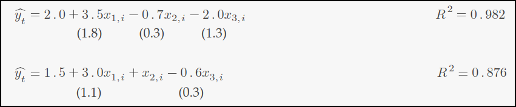

donde las cifras entre paréntesis representan las desviaciones típicas de los estimadores. Se pide:

1. ¿Qué restricciones lineales incorpora la estimación (2) respecto de la estimación (1)?
2. Contraste la hipótesis nula especificada en el apartado previo

## Ejercicio 12 (sleep)

El archivo `datos_sleep75.gdt` (Introductory Econometrics, Jeffrey M. Wooldridge) incluye las siguientes variables de una muestra de 706 persones adultas:

- **SLEEP**: Tiempo de sueño cada semana (en minutos)
- **EDUC**: Años de educación
- **TOTWRK**: Tiempo de trabajo cada semana (en minutos)
- **AGE**: Edad en años

Con estos datos estime el siguiente modelo: $SLEEP_{i} = \beta_{1} + \beta_{2} TOTWORK_{i} + \beta_{3} EDUC_{i} + \beta_{4} AGE_{i}+ u_{i}$

1. ¿Cuánto dormirá diariamente una persona de 20 años de edad, con 14 de educación y que trabaja 40 horas semanales?
2. Analice la significatividad de cada una de las variables
3. Analice la significatividad conjunta del Modelo 1
4. Al trabajar más, ¿se duerme menos?
5. ¿Una hora adicional de trabajo implica quince minutos menos de sueño?
6. ¿Una hora adicional de trabajo implica diez minutos menos de sueño?
7. ¿Influyen la educación y la edad conjuntamente en el tiempo de sueño?

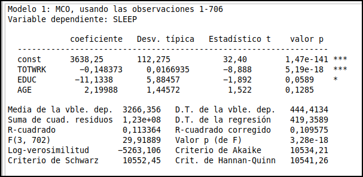

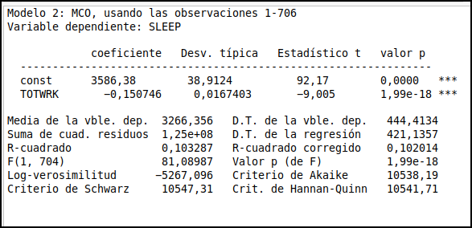

## Ejercicio 13

(Examen de julio de 2007). Argumente la veracidad o falsedad de las siguientes afirmaciones:

1. En un modelo de regresión, los residuos son iguales a las perturbaciones aleatorias
2. En un modelo de regresión, el coeficiente de determinación ( $R^{2}$ ) es igual al coeficiente de determinación corregido ( $\overline{R^{2}}$ )

## Ejercicio 14 (sleep)

El archivo `datos_sleep75.gdt` (Introductory Econometrics, Jeffrey M. Wooldridge) incluye las siguientes variables de una muestra de 706 persones adultas:

- **SLEEP**: Tiempo de sueño cada semana (en minutos)
- **EDUC**: Años de educación
- **TOTWRK**: Tiempo de trabajo cada semana (en minutos)
- **AGE**: Edad en años

Con estos datos estime el siguiente modelo: $SLEEP_{i} = \beta_{1} + \beta_{2} TOTWORK_{i} + \beta_{3} EDUC_{i} + \beta_{4} AGE_{i}+ u_{i}$

1. Interprete la estimación de $\beta_{2}$
2. ¿Cómo cambiará la estimación de $\beta_{2}$ si el tiempo de trabajo pasase a medirse en horas por semana?
3. ¿Cómo cambiará la estimación de $\beta_{2}$ si el tiempo de trabajo pasase a medirse en días por semana?
4. ¿Cómo cambiará la estimación de $\beta_{2}$ si el tiempo de sueño pasase a medirse en horas por semana?
5. ¿Cómo cambiará la estimación de $\beta_{2}$ si las dos variables, tanto el tiempo de sueño como el tiempo de trabajo se midiesen en horas por semana?

## Ejercicio 15

El archivo `datos_alim.gdt` contiene las siguientes variables:

- **ALIM**: Gasto familiar en alimentos (en euros anuales)
- **RDISP**: Renta familiar disponible (en euros anuales)

Estima e interpreta la estimación de $\beta_{2}$ en los siguientes modelos:

1. $ALIM_{i} = \beta_{1} + \beta_{2}RDISP_{i}$
2. $LN (ALIM_{i}) = \beta_{1} + \beta_{2}RDISP_{i}$
3. $ALIM_{i} = \beta_{1} + \beta_{2} LN(RDISP_{i})$
4. $LN (ALIM_{i}) = \beta_{1} + \beta_{2} LN(RDISP_{i})$

## Ejercicio 16

(Examen de julio de 2008) Razona la veracidad o falsedad de las siguientes afirmaciones, en el siguiente modelo:

$$ln(y_{i} ) = \beta_{1} + \beta_{2} x_{2i} + \beta_{3} ln(x_{3i}) + u_{i}$$

1. Cuando la variable $x_{2}$ aumenta una unidad, la variable $y$ experimenta una tasa de variación porcentual igual a $\beta_{2}$
2. Cuando la variable $x_{3}$ aumenta una unidad, la variable $y$ aumenta $\beta_{3}$ unidades

## Ejercicio 17

(Examen de junio de 2012). Argumente la veracidad o falsedad de las siguientes afirmaciones utilizando los siguientes modelos de regresión estimados:

$$\widehat{ln(y_{i})} = 3 + 0,17 x_{2i} -1,4 ln(x_{3i})$$

$$\widehat{y_{i}} = 2 - 9,3 ln(x_{4i}) + 3,5 x_{5i}$$

1. Cuando la variable $x_{2}$ aumenta en una unidad, la variable $y$ experimenta una tasa de variación igual al 17%
2. Cuando $x_{4}$ disminuye en un 9,3%, la variable $y$ disminuye en una unidad

## Ejercicio 18

Dada la función de producción Cobb-Douglas $Q = A L_{t}^{\alpha} K_{t}^{\beta}$, en la que $Q$ designa la producción, $L$ la ocupación y $K$ el capital:

1. Linealice el modelo anterior
2. Interprete los parámetros $\alpha$ y $\beta$

## Ejercicio 19 (bebes)

1. Utilice los datos del fichero `datos_bebes.gdt` para estimar los siguiente modelos e interpretar sus coeficientes:

$$[Modelo \; 1] \; \; log(peso\_bebe) = \beta_{1} + \beta_{2}log(semanas\_gestacion) + \beta_{3} edad\_madre + \beta_{4} genero\_mujer + u$$

$$[Modelo \; 2] \; \; peso\_bebe = \beta_{1} + \beta_{2}semanas\_gestacion + \beta_{3} genero\_mujer + \beta_{4} (semanas\_gestacion *estudios_primarios) + u$$

$$[Modelo \; 3] \; \; peso\_bebe = \beta_{1} + \beta_{2}semanas\_gestacion + \beta_{3} genero\_varon + \beta_{4} (semanas\_gestacion *genero\_varon) + u$$

$$[Modelo \, 4] \; \; peso\_bebe = \beta_{1} + \beta_{2}semanas\_gestacion + \beta_{3} estudios\_universitarios + \beta_{4} estudios\_medios + \; ...$$
$$... \; + \beta_{5} (semanas\_gestacion *estudios\_universitarios) + \beta_{6} (semanas\_gestacion *estudios\_medios) + u$$

2. En el último modelo, contraste si hay diferencias signficativas en el peso de los bebes asociadas a la educación de la madre.

## Ejercicio 20 (bebes)

Utilice los datos del fichero `datos_bebes.gdt` para estimar el siguiente modelo:

$$peso\_bebe = \beta_{1} + \beta_{2}semanas\_gestacion + \beta_{3} edad\_madre + \beta_{4} genero\_mujer + \beta_{5} genero\_varon + u$$

1. ¿Qué problema tiene el anterior modelo? Explique detalladamente

## Ejercicio 21 (pescado)

Con los datos del archivo `datos_pescado.gdt` se ha estimado el siguiente modelo:

$$PESCADO_{i} = \beta{1} + \beta{2} \; RDISP_{i} + \beta{3} \; ESTMED_{i} + \beta{4} \; ESTSUP_{i} + ui_{i}$$

Donde:

- **PESCADO**: Gasto anual en pescado en miles de pesetas per cápita
- **RDISP**: Renta anual disponible en miles de pesetas per cápita
- **ESTMED**: Variable ficticia que toma el valor 1 si el máximo nivel de estudios obtenido por el sustentador principal ha sido el de estudios medios y 0 en caso contrario
- **ESTSUP**: Variable ficticia que toma el valor 1 si el máximo nivel de estudios obtenido por el sustentador principal ha sido el de estudios superiores y 0 en caso contrario
1. ¿Cuál es el nivel de estudios de referencia? Interprete las estimaciones de $\beta_{3}$ y $\beta_{4}$
2. Contraste si el gasto en pescado es igual para las familias con con estudios básicos y con estudios superiores
3. Contraste si el gasto en pescado es igual con estudios medios y con estudios superiores
4. Indique las consecuencias de introducir una nueva variable ficticia que tome el valor 1 si el máximo nivel de estudios obtenido por el sustentador principal ha sido el de estudios básicos y 0 en caso contrario

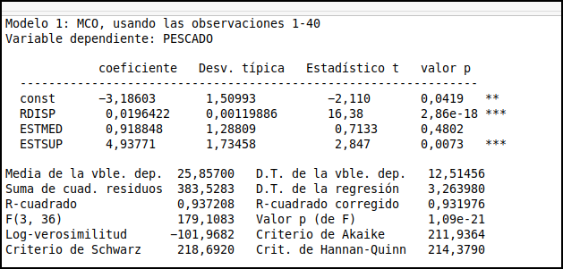

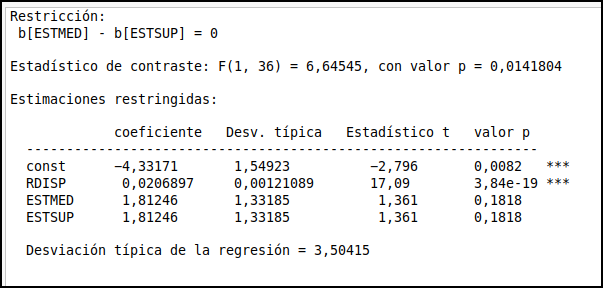

## Ejercicio 22

(Examen febrero 2006) Con una muestra formada por 25 trabajadores se han obtenido las siguientes estimaciones:

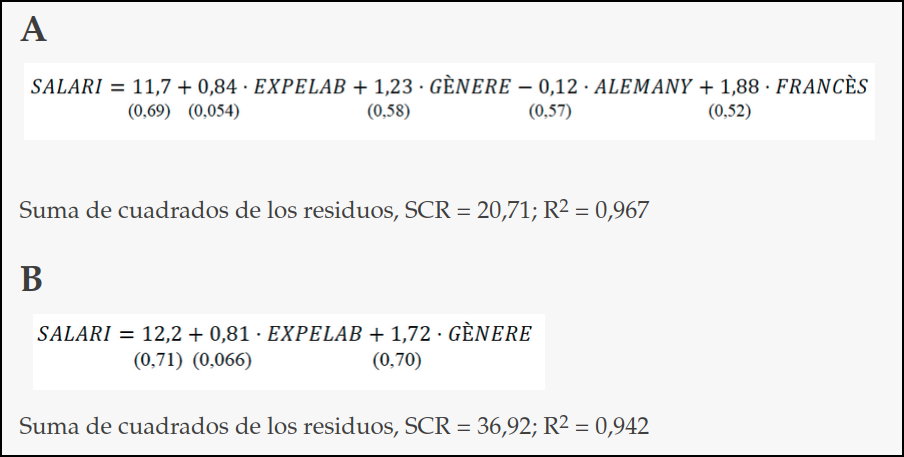

donde:

- **SALARI**: Salario bruto anual del trabajador en miles de euros
- **EXPELAB**: Experiencia laboral del trabajador en años
- **GÈNERE**: Variable ficticia que toma el valor 1 si el trabajador es un hombre y 0 en caso contrario
- **ALEMANY**: Variable ficticia que toma el valor 1 si el trabajador sabe alemán y 0 en caso contrario
- **FRANCÈS**: Variable ficticia que toma el valor 1 si el trabajador sabe francés y 0 en caso contrario

y los valores entre paréntesis son los errores estándar.

1. ¿Influye la experiencia laboral en el salario? (Tome como referencia el Modelo A)
2. ¿Influye el conocimiento de los dos idiomas extranjeros en el salario de un trabajador?
3. ¿Qué diferencia salarial cabe esperar entre un hombre sin conocimientos de francés y una mujer con conocimientos de francés?
4. Plantee un modelo de regresión que permita analizar si la diferencia salarial entre hombres y mujeres aumenta con la experiencia laboral e indique cómo realizaría el contraste pertinente. (Tome como referencia el Modelo B)

## Ejercicio 23

Con datos trimestrales comprendidos entre el primer trimestre de 1981 y el cuarto trimestre de 2008 se ha obtenido la siguiente estimación:

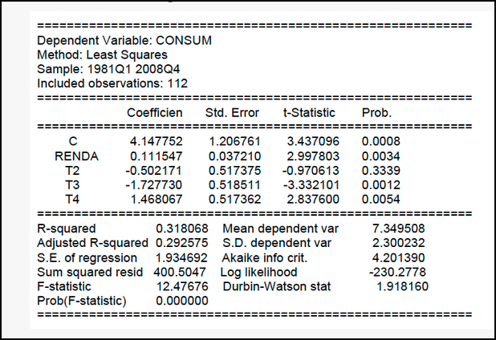

donde CONSUM es el consumo en miles de euros, RENDA es la renta en miles de euros, y T2, T3 y T4 son variables ficticias que toman el valor 1 en el segundo, tercer y cuarto trimestre, respectivamente, y 0 en los respectivos casos contrarios.

1. ¿Difiere el consumo en el primer y segundo trimestre?
2. ¿Es el consumo menor en el segundo trimestre que en el primero?
3. ¿Qué contraste plantearía para analizar si existe estacionalidad o diferencias entre los trimestres?
4. Se introduce una nueva ficticia, T1, que toma el valor 1 en el primer trimestre y 0 en los otros trimestres. ¿Qué ocurrirá?

## Ejercicio 24

El archivo `datos_salario.gdt` tiene información de las siguientes variables:

- **SALARI**: Salario del trabajador en euros brutos anuales.
- **EXPLAB**: Experiencia laboral del trabajador en años.
- **GENERE**: Variable ficticia que toma el valor 1 para los hombres y 0 para las mujeres
1. Estime el siguiente modelo $SALARI_{i} = \beta_{1} + \beta_{2} EXPLAB_{i} + \beta_{3} GENERE_{i} + u_{i}$
2. ¿Cuál es el género de referencia?
3. Interprete los parámetros $\beta_{2}$ y $\beta_{3}$ , y sus estimaciones
4. ¿Influye la experiencia laboral en el salario?
5. ¿Cuánto puede esperarse que aumente el salario si aumenta su experiencia laboral en un año?
6. Considerando las estimaciones, ¿hay discriminación laboral por género?
7. Según el modelo estimado, ¿qué proporción de las variaciones salariales son explicadas por los factores género y experiencia?
8. Supón ahora que el valor 1 de la variable GENERE corresponde a las mujeres y el 0 a los hombres. ¿Cómo se interpretará ahora el parámetro que acompaña a esta variable?
9. Suponga que definimos las siguientes variables ficticias: HOME (con valor 1 para los hombres y 0 para las mujeres) y DONA (con valor 1 para las mujeres y 0 para los hombres). ¿Qué ocurrirá al estimar lo siguientes 3 modelos?

$$SALARI_{i} = \beta_{1} + \beta_{2} EXPLAB_{i} + \beta_{3} GENERE_{i} + \beta_{4} HOME_{i} + u_{i}$$

$$SALARI_{i} = \beta_{1} + \beta_{2} EXPLAB_{i} + \beta_{3} GENERE_{i} + \beta_{4} DONA_{i} + u_{i}$$

$$SALARI_{i} = \beta_{1} + \beta_{2} EXPLAB_{i} + \beta_{3} HOME_{i} + \beta_{4} DONA_{i} + u_{i}$$

10. Estima ahora un modelo que permita analizar si la experiencia laboral se retribuye de igual manera para hombres y mujeres. Analice los resultados

## Ejercicio 25

El archivo `datos_ocio.gdt` contiene información de las siguientes variables:

- **OCI**: Gasto en ocio en euros anuales
- **RENDA**: Renata disponible en euros anuales
- **PRIM**: Variable ficticia que toma el valor 1 si el máximo nivel de estudios conseguidos es el nivel primario y 0 en caso contrario
- **SEC**: Variable ficticia que toma el valor 1 si el máximo nivel de estudios conseguidos es el nivel secundario y 0 en caso contrario
- **UNI**: Variable ficticia que toma el valor 1 si el máximo nivel de estudios conseguidos son estudios universitarios y 0 en caso contrario
1. Plantee un modelo teórico sin interacciones entre variables explicativas que permita explicar el gasto en ocio a partir de la renta disponible y el nivel de estudios. ¿Cuál es el nivel de estudios de referencia?
2. Interprete los parámetros del modelo anterior
3. Estime el modelo planteado
4. Considerando el modelo estimado en el apartado c), ¿existen diferencias significativas en el gasto en ocio entre las personas con estudios secundarios y las personas con estudios primarios?
5. Considerando el modelo estimado en el apartado c), ¿existen diferencias significativas en el gasto en ocio entre las personas con estudios universitarios y las personas con estudios primarios?
6. Considerando el modelo estimado en el apartado c), ¿existen diferencias significativas en el gasto en ocio entre las personas con estudios secundarios y las personas con estudios universitarios?
7. Especifique ahora un modelo que incluya interacciones entre la renta y el nivel de estudios
8. Interprete los parámetros del modelo anterior
9. Estime el modelo planteado
10. Considerando el modelo estimado en el apartado i), ¿existen diferencias significativas en el gasto en ocio entre las personas con estudios secundarios y las personas con estudios universitarios?
11. Considerando el modelo estimado en el apartado i), construya una tabla de doble entrada que muestre el gasto en ocio imputable a las personas con rentas iguales a 10.000, 20.000 y 30.000 euros y con diferentes niveles de estudios

## Ejercicio 26

(Examen de enero de 2012). Para analizar las retribuciones salariales de determinados profesionales sanitarios, se plantea el siguiente modelo:

$$SAL_{i} = \beta_{1} + \beta_{2} EXPLAB_{i} + \beta_{3} GENERE_{i} + \beta_{4} NACIO_{i} + \beta_{5} (GENERE_{i} \times NACIO_{i}) + u_{i}$$

- **$SAL$** : Salario en euros anuales
  - **$EXPLAB$**: Experiencia laboral en años
  - **$GENERE$**: Variable ficticia que toma el valor 1 si el profesional es hombre y 0 en caso contrario
  - **$NACIO$**: Variable ficticia que toma el valor 1 si el profesional tiene nacionalidad española y 0 en caso contrario
1. ¿Qué salario cabe esperar para cada una de las posibles combinaciones de género y nacionalidad?
2. Interprete el significado de $\beta_{5}$

## Ejercicio 27 (bebes)

Utilice los datos del fichero “datos_bebes.gdt” para estimar el siguiente modelo:

$$peso\_bebe = \beta_{1} + \beta_{2}semanas\_gestacion + \beta_{3} edad\_madre + \beta_{4} genero\_varon + u$$

1. ¿cree que el modelo tiene problemas serios de colinealidad entre los regresores? Explique
2. Suponga que sí que hubiese un problema importante de colinealidad ¿cuales serían las consecuencias?
3. Contraste la normalidad de las perturbaciones. Explique el resultado y las consecuencias del contraste
4. Efectúe el test RESET de Ramsey y explique los resultados
5. Efectúe el test de White para contrastar la homocedasticidad de las perturbaciones. Explique el contraste y las consecuencias de su resultado